# Envirnoment and field model analysis

Chelsey Wegener

26 July, 2021

**Goal of this markdown:** Using a AIC model ranking to analyze my evironmental and field data. Looking at models with environmental data fitlered between field surveys, one month (30 days) before field surveys, and two months (60 days) before field surveys.

I am addressing research question #3:  
Is variation in salinity, air temperature, or pH associated with changes in abundances or reproductive effort of F. distichus populations in SFE? –> compare models and see which ones have the most evidence (based on fit of model and evidence)  
- assumptions: environmental variables matter (lit evidence and prior knowledge)  
- Environmental variables have been filtered for tides

AIC link:  
https://www.statology.org/aic-in-r/

**Models**  
I’ll try the same model list with a one month lag and then a two month lag. Focusing on 1) daily salinity range and low salinity events (number of days with a daily maximum less than 10), 2) high air temperature events (number of days with a maximum daily temperature over 26C) , 3) daily pH range and high pH events, and 4) adult cover (large thalli density). Previously I tested both raw and square root transformed for juvenile abundance and the untransformed data fit better and had a higher R^2.

1. Juv ~ adult cover + daily salinity range + high air temp event + daily pH range + adult cover: daily air temp event
2. Juv ~ adult cover + low salinity event + high air temp event + high pH event + adult cover : high air temp event
3. Juv ~ adult cover + daily salinity range + high air temp event + adult cover : high air temp event 4. Juv ~ adult cover + low salinity event + high air temp event + adult cover : high air temp event
4. Juv ~ adult cover + high air temp event + adult cover : high air temp event
5. Juv ~ adult cover + daily salinity range + high air temp event
6. Juv ~ low salinity event + high pH event + high air temp event
7. Juv ~ daily salinity range + daily pH range + high air temp event
8. Juv ~ adult cover + high air temp event
9. Juv ~ daily salinity range + daily pH range
10. Juv ~ low salinity event + high pH event
11. Juv ~ low salinity event + high air temp event

**outliers** 3: highest mean juvenile denisty 4: third highest mean juvenile density 32: fourth highest mean juvenile density 37: CODING ERROR with max daily air temp greater than 26 –> result of a coding error I found, fixed, and checked for at all sites. No long an outlier

**Next steps** - try median instead of mean juvenile abundance

Set up  
Loading packages, reading in and prepping data

```r
rm(list=ls())

library(tidyverse)
library(ggpubr)
library(scales)
library(chron)
library(plotly)
library(taRifx)
library(aweek)
library(easypackages)
library(renv)
library(here)
library(ggthemes)
library(gridExtra)
library(patchwork)
library(tidyquant)
library(recipes)
library(cranlogs)
library(knitr)
library(openair)
library(xts)
library(dplyr)

#AIC
library(AICcmodavg)
library(plm) #for random factors
library(lme4)
library(car)

#Table
library(sjPlot)
library(sjmisc)
library(sjlabelled)
library(insight)
library(tibble)
```

#### Envirnomental data fitlered 30 days before field survey

Envirnomental data 30 days leading up to survey day (excluding day of survey) and adult thalli density from the field survey one month before. Juvenile density is the mean.

Read in data

```r
#read in data
one.month<-read.csv(
      "https://raw.githubusercontent.com/Cmwegener/thesis/master/data/environment_field/envi.field.all.one.month.lag.csv",
    header = TRUE
  )
one.month$date<-as.Date(one.month$date, format = c("%Y-%m-%d"))
```

AIC

```r
#models
m1 <- lm(no.small.fuc.q ~ lag.no.large.fuc.q + daily.sal.range + max.daily.air.gt26 + daily.ph.range + lag.no.large.fuc.q:max.daily.air.gt26, data=one.month)

m2 <- lm(no.small.fuc.q ~ lag.no.large.fuc.q + max.daily.sal.lt10 + max.daily.air.gt26 + max.daily.ph.gt8 + lag.no.large.fuc.q:max.daily.air.gt26, data=one.month)

m3 <- lm(no.small.fuc.q ~ lag.no.large.fuc.q + daily.sal.range + max.daily.air.gt26 + lag.no.large.fuc.q:max.daily.air.gt26, data=one.month)

m4 <- lm(no.small.fuc.q ~ lag.no.large.fuc.q + max.daily.sal.lt10 + max.daily.air.gt26 + lag.no.large.fuc.q:max.daily.air.gt26, data=one.month)

m5 <- lm(no.small.fuc.q ~ lag.no.large.fuc.q + max.daily.air.gt26 + lag.no.large.fuc.q:max.daily.air.gt26, data=one.month)

m6 <- lm(no.small.fuc.q ~ lag.no.large.fuc.q + daily.sal.range + max.daily.air.gt26, data=one.month)

m7 <- lm(no.small.fuc.q ~ max.daily.sal.lt10 + max.daily.ph.gt8 + max.daily.air.gt26, data=one.month)

m8 <- lm(no.small.fuc.q ~ daily.sal.range + daily.ph.range + max.daily.air.gt26, data=one.month)

m9 <- lm(no.small.fuc.q ~ lag.no.large.fuc.q + max.daily.air.gt26, data=one.month)

m10 <- lm(no.small.fuc.q ~ daily.sal.range + daily.ph.range, data=one.month)

m11 <- lm(no.small.fuc.q ~ max.daily.sal.lt10 + max.daily.ph.gt8, data=one.month)

m12 <- lm(no.small.fuc.q ~ max.daily.sal.lt10 + max.daily.air.gt26, data=one.month)

#define list of models
models <- list(m1,m2,m3,m4,m5,m6,m7,m8,m9,m10,m11,m12)

#specify model names- just keeping them the same
mod.names <- c('m1','m2','m3','m4', 'm5','m6','m7','m8', 'm9','m10', 'm11','m12')

#calculate AIC of each model
aictab(cand.set = models, modnames = mod.names)
```

```
##
## Model selection based on AICc:
##
##     K   AICc Delta_AICc AICcWt Cum.Wt      LL
## m1  7 395.48       0.00   0.96   0.96 -188.93
## m2  7 401.78       6.30   0.04   1.00 -192.09
## m8  5 424.88      29.40   0.00   1.00 -206.61
## m10 4 425.32      29.84   0.00   1.00 -208.12
## m11 4 430.60      35.12   0.00   1.00 -210.76
## m7  5 433.06      37.58   0.00   1.00 -210.70
## m6  5 515.41     119.92   0.00   1.00 -252.06
## m3  6 517.94     122.46   0.00   1.00 -252.06
## m9  4 521.93     126.45   0.00   1.00 -256.55
## m5  5 524.24     128.75   0.00   1.00 -256.48
## m4  6 526.78     131.30   0.00   1.00 -256.48
## m12 4 569.63     174.15   0.00   1.00 -280.43
```

**Top ranked**  
m1 <- lm(no.small.fuc.q ~ lag.no.large.fuc.q + daily.sal.range + max.daily.air.gt26 + daily.ph.range + lag.no.large.fuc.q:max.daily.air.gt26, data=one.month)  
Fitting and analyzing the top ranked model.

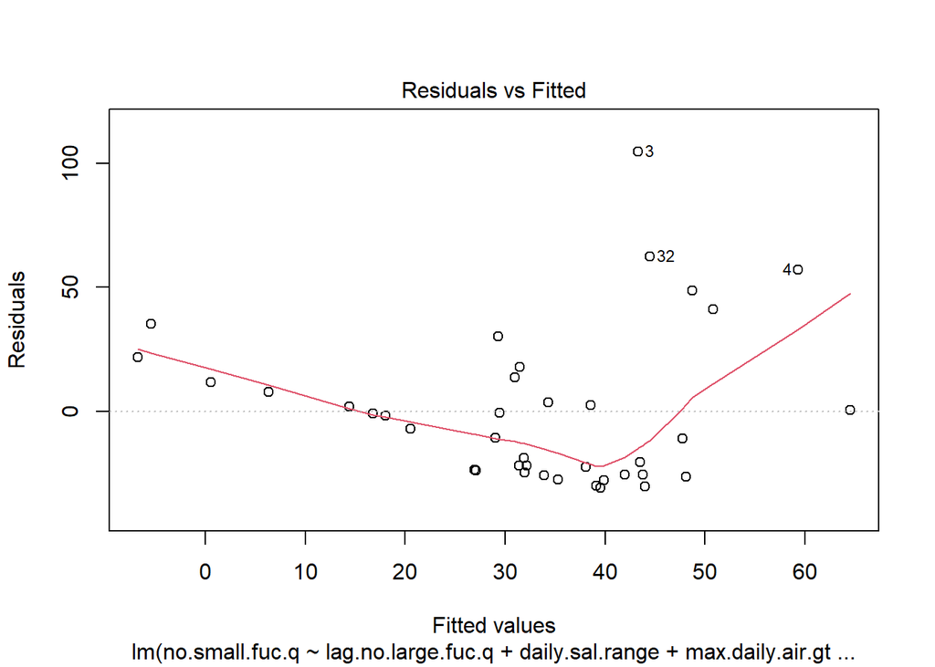

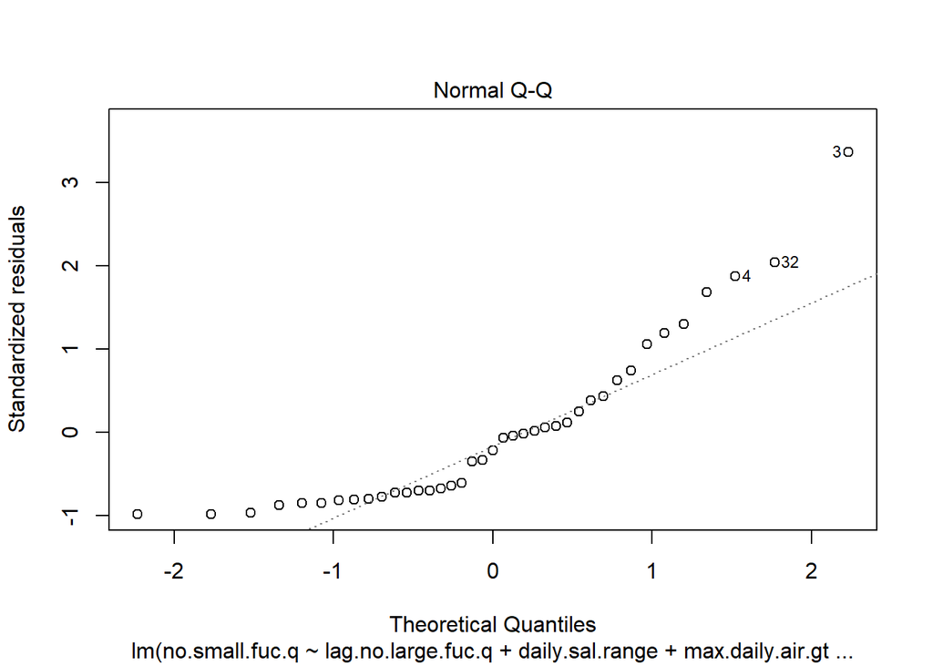

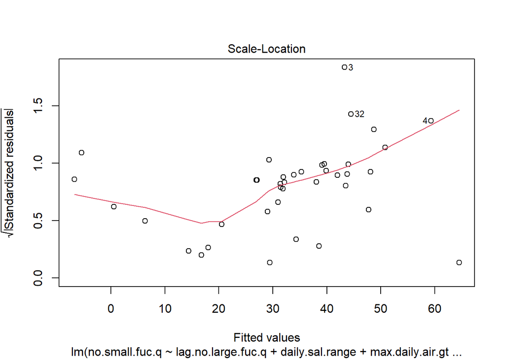

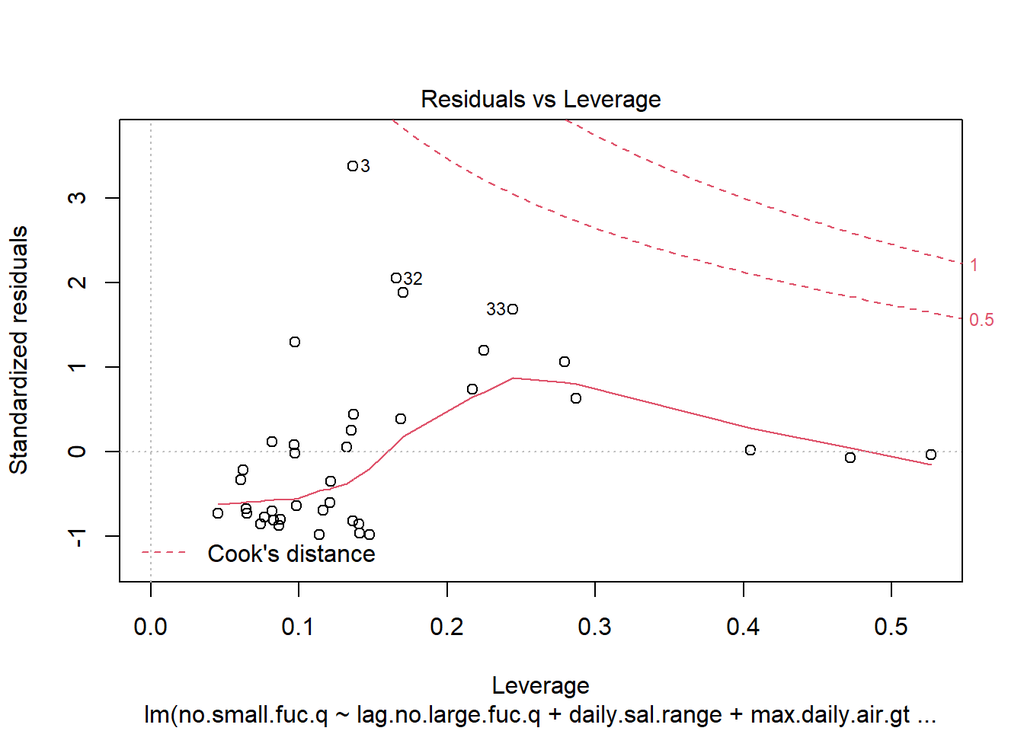

```r
m1 <- lm(no.small.fuc.q ~ lag.no.large.fuc.q + daily.sal.range + max.daily.air.gt26 + daily.ph.range + lag.no.large.fuc.q:max.daily.air.gt26, data=one.month)
plot(m1)
```

```r
m1
```

```
##
## Call:
## lm(formula = no.small.fuc.q ~ lag.no.large.fuc.q + daily.sal.range +
##     max.daily.air.gt26 + daily.ph.range + lag.no.large.fuc.q:max.daily.air.gt26,
##     data = one.month)
##
## Coefficients:
##                           (Intercept)                     lag.no.large.fuc.q
##                             58.753199                               1.000281
##                       daily.sal.range                     max.daily.air.gt26
##                             -4.504252                              -0.790638
##                        daily.ph.range  lag.no.large.fuc.q:max.daily.air.gt26
##                             -1.891923                               0.002399
```

```r
summary(m1)
```

```
##
## Call:
## lm(formula = no.small.fuc.q ~ lag.no.large.fuc.q + daily.sal.range +
##     max.daily.air.gt26 + daily.ph.range + lag.no.large.fuc.q:max.daily.air.gt26,
##     data = one.month)
##
## Residuals:
##     Min      1Q  Median      3Q     Max
## -31.061 -24.344  -7.122  12.649 104.767
##
## Coefficients:
##                                        Estimate Std. Error t value Pr(>|t|)
## (Intercept)                           58.753199  20.286896   2.896  0.00666 **
## lag.no.large.fuc.q                     1.000281   1.342969   0.745  0.46165
## daily.sal.range                       -4.504252   1.774704  -2.538  0.01605 *
## max.daily.air.gt26                    -0.790638   0.882614  -0.896  0.37685
## daily.ph.range                        -1.891923   3.429397  -0.552  0.58489
## lag.no.large.fuc.q:max.daily.air.gt26  0.002399   0.094643   0.025  0.97993
## ---
## Signif. codes:  0 '***' 0.001 '**' 0.01 '*' 0.05 '.' 0.1 ' ' 1
##
## Residual standard error: 33.42 on 33 degrees of freedom
##   (22 observations deleted due to missingness)
## Multiple R-squared:  0.2047, Adjusted R-squared:  0.0842
## F-statistic: 1.699 on 5 and 33 DF,  p-value: 0.1624
```

```r
anova(m1)
```

```
## Analysis of Variance Table
##
## Response: no.small.fuc.q
##                                       Df Sum Sq Mean Sq F value  Pr(>F)
## lag.no.large.fuc.q                     1   1580  1580.1  1.4150 0.24271
## daily.sal.range                        1   5706  5706.1  5.1099 0.03051 *
## max.daily.air.gt26                     1   1857  1856.8  1.6628 0.20620
## daily.ph.range                         1    341   340.9  0.3053 0.58429
## lag.no.large.fuc.q:max.daily.air.gt26  1      1     0.7  0.0006 0.97993
## Residuals                             33  36850  1116.7
## ---
## Signif. codes:  0 '***' 0.001 '**' 0.01 '*' 0.05 '.' 0.1 ' ' 1
```

```r
confint(m1)
```

```
##                                            2.5 %      97.5 %
## (Intercept)                           17.4791983 100.0271992
## lag.no.large.fuc.q                    -1.7320093   3.7325716
## daily.sal.range                       -8.1149154  -0.8935885
## max.daily.air.gt26                    -2.5863298   1.0050534
## daily.ph.range                        -8.8690826   5.0852374
## lag.no.large.fuc.q:max.daily.air.gt26 -0.1901534   0.1949505
```

Table

```r
tab_model(m1)
```

|  | no.small.fuc.q |  |  |
| --- | --- | --- | --- |
| Predictors | Estimates | CI | p |
| (Intercept) | 58.75 | 17.48 – 100.03 | **0.007** |
| lag.no.large.fuc.q | 1.00 | -1.73 – 3.73 | 0.462 |
| daily.sal.range | -4.50 | -8.11 – -0.89 | **0.016** |
| max.daily.air.gt26 | -0.79 | -2.59 – 1.01 | 0.377 |
| daily.ph.range | -1.89 | -8.87 – 5.09 | 0.585 |
| lag.no.large.fuc.q * max.daily.air.gt26 | 0.00 | -0.19 – 0.19 | 0.980 |
| Observations | 39 |  |  |
| R<sup>2</sup> / R<sup>2</sup> adjusted | 0.205 / 0.084 |  |  |

**Second ranked**  
m2 <- lm(no.small.fuc.q ~ lag.no.large.fuc.q + max.daily.sal.lt10 + max.daily.air.gt26 + max.daily.ph.gt8 + lag.no.large.fuc.q:max.daily.air.gt26, data=one.month) Fitting and analyzing the top ranked model.

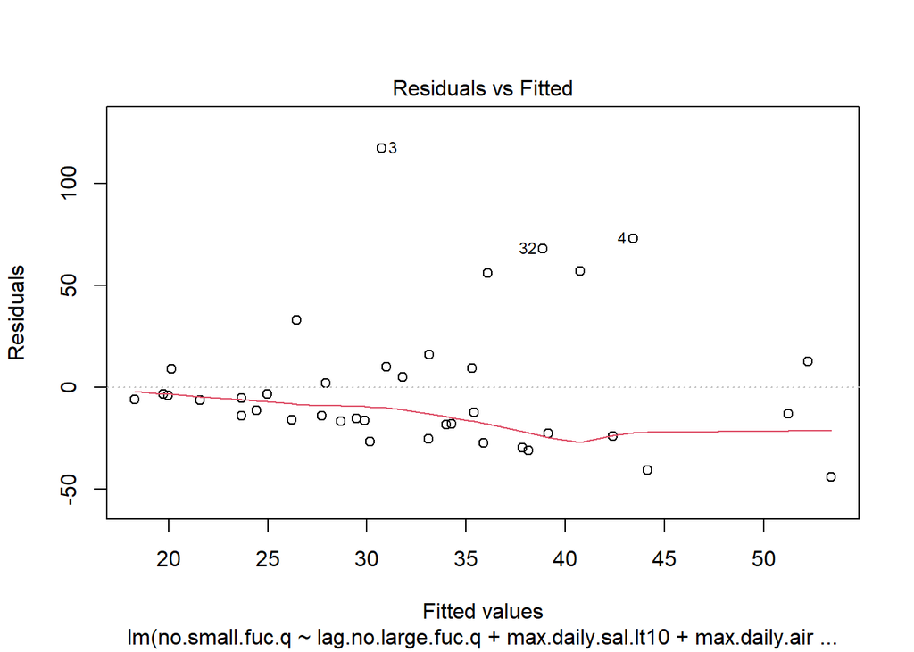

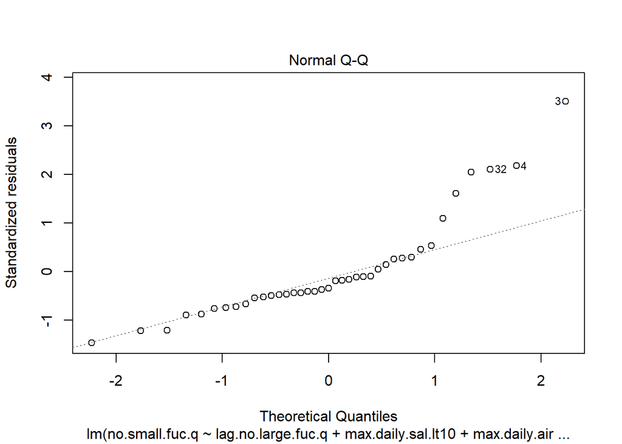

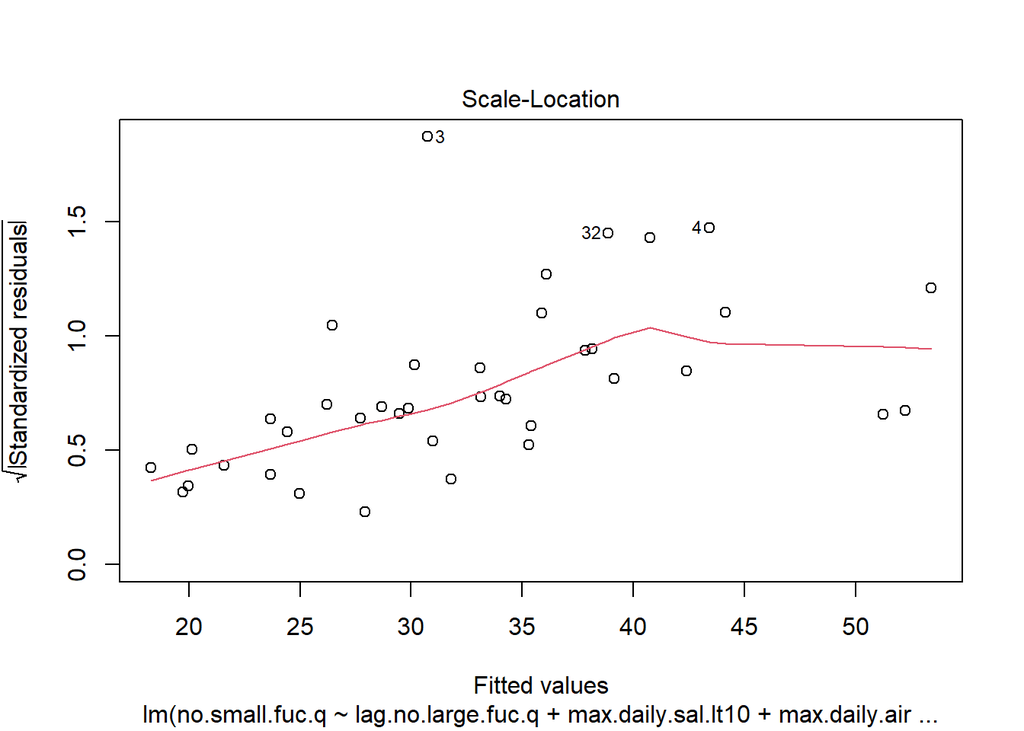

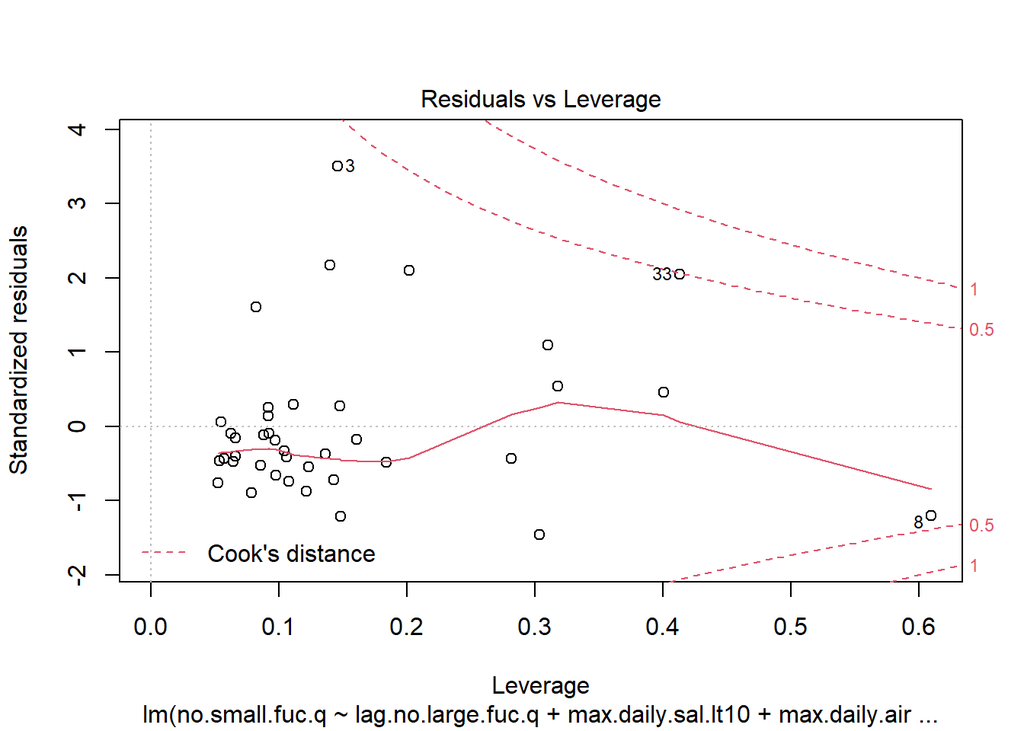

```r
m2 <- lm(no.small.fuc.q ~ lag.no.large.fuc.q + max.daily.sal.lt10 + max.daily.air.gt26 + max.daily.ph.gt8 + lag.no.large.fuc.q:max.daily.air.gt26, data=one.month)
plot(m2)
```

```r
m2
```

```
##
## Call:
## lm(formula = no.small.fuc.q ~ lag.no.large.fuc.q + max.daily.sal.lt10 +
##     max.daily.air.gt26 + max.daily.ph.gt8 + lag.no.large.fuc.q:max.daily.air.gt26,
##     data = one.month)
##
## Coefficients:
##                           (Intercept)                     lag.no.large.fuc.q
##                             15.677698                               1.537695
##                    max.daily.sal.lt10                     max.daily.air.gt26
##                             -0.384003                               0.051113
##                      max.daily.ph.gt8  lag.no.large.fuc.q:max.daily.air.gt26
##                              0.676607                               0.006729
```

```r
summary(m2)
```

```
##
## Call:
## lm(formula = no.small.fuc.q ~ lag.no.large.fuc.q + max.daily.sal.lt10 +
##     max.daily.air.gt26 + max.daily.ph.gt8 + lag.no.large.fuc.q:max.daily.air.gt26,
##     data = one.month)
##
## Residuals:
##     Min      1Q  Median      3Q     Max
## -44.297 -18.246 -11.544   8.979 117.353
##
## Coefficients:
##                                        Estimate Std. Error t value Pr(>|t|)
## (Intercept)                           15.677698  13.880438   1.129    0.267
## lag.no.large.fuc.q                     1.537695   1.412855   1.088    0.284
## max.daily.sal.lt10                    -0.384003   2.730995  -0.141    0.889
## max.daily.air.gt26                     0.051113   0.890520   0.057    0.955
## max.daily.ph.gt8                       0.676607   0.899435   0.752    0.457
## lag.no.large.fuc.q:max.daily.air.gt26  0.006729   0.102540   0.066    0.948
##
## Residual standard error: 36.23 on 33 degrees of freedom
##   (22 observations deleted due to missingness)
## Multiple R-squared:  0.06521,    Adjusted R-squared:  -0.07642
## F-statistic: 0.4604 on 5 and 33 DF,  p-value: 0.8027
```

```r
anova(m2)
```

```
## Analysis of Variance Table
##
## Response: no.small.fuc.q
##                                       Df Sum Sq Mean Sq F value Pr(>F)
## lag.no.large.fuc.q                     1   1580 1580.11  1.2039 0.2805
## max.daily.sal.lt10                     1     88   87.93  0.0670 0.7974
## max.daily.air.gt26                     1    611  610.56  0.4652 0.5000
## max.daily.ph.gt8                       1    737  737.30  0.5617 0.4589
## lag.no.large.fuc.q:max.daily.air.gt26  1      6    5.65  0.0043 0.9481
## Residuals                             33  43313 1312.53
```

```r
confint(m2)
```

```
##                                             2.5 %     97.5 %
## (Intercept)                           -12.5622666 43.9176619
## lag.no.large.fuc.q                     -1.3367796  4.4121702
## max.daily.sal.lt10                     -5.9402538  5.1722480
## max.daily.air.gt26                     -1.7606630  1.8628891
## max.daily.ph.gt8                       -1.1533069  2.5065202
## lag.no.large.fuc.q:max.daily.air.gt26  -0.2018911  0.2153492
```

Table

```r
tab_model(m2)
```

|  | no.small.fuc.q |  |  |
| --- | --- | --- | --- |
| Predictors | Estimates | CI | p |
| (Intercept) | 15.68 | -12.56 – 43.92 | 0.267 |
| lag.no.large.fuc.q | 1.54 | -1.34 – 4.41 | 0.284 |
| max.daily.sal.lt10 | -0.38 | -5.94 – 5.17 | 0.889 |
| max.daily.air.gt26 | 0.05 | -1.76 – 1.86 | 0.955 |
| max.daily.ph.gt8 | 0.68 | -1.15 – 2.51 | 0.457 |
| lag.no.large.fuc.q * max.daily.air.gt26 | 0.01 | -0.20 – 0.22 | 0.948 |
| Observations | 39 |  |  |
| R<sup>2</sup> / R<sup>2</sup> adjusted | 0.065 / -0.076 |  |  |

#### Envirnomental data fitlered 60 days before field survey

Envirnomental data for 30 days starting 60 days from survey date (excludes the 30 days leading up to the survey date). Adult thalli density from two surveys/months before. Juvenile density is the mean.

Read in data

```r
#read in data
two.month<-read.csv(
      "https://raw.githubusercontent.com/Cmwegener/thesis/master/data/environment_field/envi.field.all.two.month.lag.csv",
    header = TRUE
  )
two.month$date<-as.Date(two.month$date, format = c("%Y-%m-%d"))
```

AIC

```r
#models
m1 <- lm(no.small.fuc.q ~ lag.no.large.fuc.q + daily.sal.range + max.daily.air.gt26 + daily.ph.range + lag.no.large.fuc.q:max.daily.air.gt26, data=two.month)

m2 <- lm(no.small.fuc.q ~ lag.no.large.fuc.q + max.daily.sal.lt10 + max.daily.air.gt26 + max.daily.ph.gt8 + lag.no.large.fuc.q:max.daily.air.gt26, data=two.month)

m3 <- lm(no.small.fuc.q ~ lag.no.large.fuc.q + daily.sal.range + max.daily.air.gt26 + lag.no.large.fuc.q:max.daily.air.gt26, data=two.month)

m4 <- lm(no.small.fuc.q ~ lag.no.large.fuc.q + max.daily.sal.lt10 + max.daily.air.gt26 + lag.no.large.fuc.q:max.daily.air.gt26, data=two.month)

m5 <- lm(no.small.fuc.q ~ lag.no.large.fuc.q + max.daily.air.gt26 + lag.no.large.fuc.q:max.daily.air.gt26, data=two.month)

m6 <- lm(no.small.fuc.q ~ lag.no.large.fuc.q + daily.sal.range + max.daily.air.gt26, data=two.month)

m7 <- lm(no.small.fuc.q ~ max.daily.sal.lt10 + max.daily.ph.gt8 + max.daily.air.gt26, data=two.month)

m8 <- lm(no.small.fuc.q ~ daily.sal.range + daily.ph.range + max.daily.air.gt26, data=two.month)

m9 <- lm(no.small.fuc.q ~ lag.no.large.fuc.q + max.daily.air.gt26, data=two.month)

m10 <- lm(no.small.fuc.q ~ daily.sal.range + daily.ph.range, data=two.month)

m11 <- lm(no.small.fuc.q ~ max.daily.sal.lt10 + max.daily.ph.gt8, data=two.month)

m12 <- lm(no.small.fuc.q ~ max.daily.sal.lt10 + max.daily.air.gt26, data=two.month)

#define list of models
models <- list(m1,m2,m3,m4,m5,m6,m7,m8,m9,m10,m11,m12)

#specify model names- just keeping them the same
mod.names <- c('m1','m2','m3','m4', 'm5','m6','m7','m8', 'm9','m10', 'm11','m12')

#calculate AIC of each model
aictab(cand.set = models, modnames = mod.names)
```

```
##
## Model selection based on AICc:
##
##     K   AICc Delta_AICc AICcWt Cum.Wt      LL
## m1  7 347.63       0.00   0.69   0.69 -164.82
## m2  7 349.20       1.57   0.31   1.00 -165.60
## m10 4 428.06      80.42   0.00   1.00 -209.49
## m11 4 429.37      81.73   0.00   1.00 -210.14
## m8  5 429.76      82.12   0.00   1.00 -209.05
## m7  5 431.93      84.29   0.00   1.00 -210.13
## m9  4 449.02     101.39   0.00   1.00 -220.06
## m6  5 451.25     103.61   0.00   1.00 -219.93
## m5  5 451.42     103.78   0.00   1.00 -220.01
## m3  6 453.76     106.13   0.00   1.00 -219.88
## m4  6 453.91     106.27   0.00   1.00 -219.95
## m12 4 567.12     219.48   0.00   1.00 -279.17
```

The top two models are the same. The main difference is that the AICcWt for the second model is much higher than the previous method (30 days leading to survey date)

**Top ranked**  
m1 <- lm(no.small.fuc.q ~ lag.no.large.fuc.q + daily.sal.range + max.daily.air.gt26 + daily.ph.range + lag.no.large.fuc.q:max.daily.air.gt26, data=two.month)  
Fitting and analyzing the top ranked model.

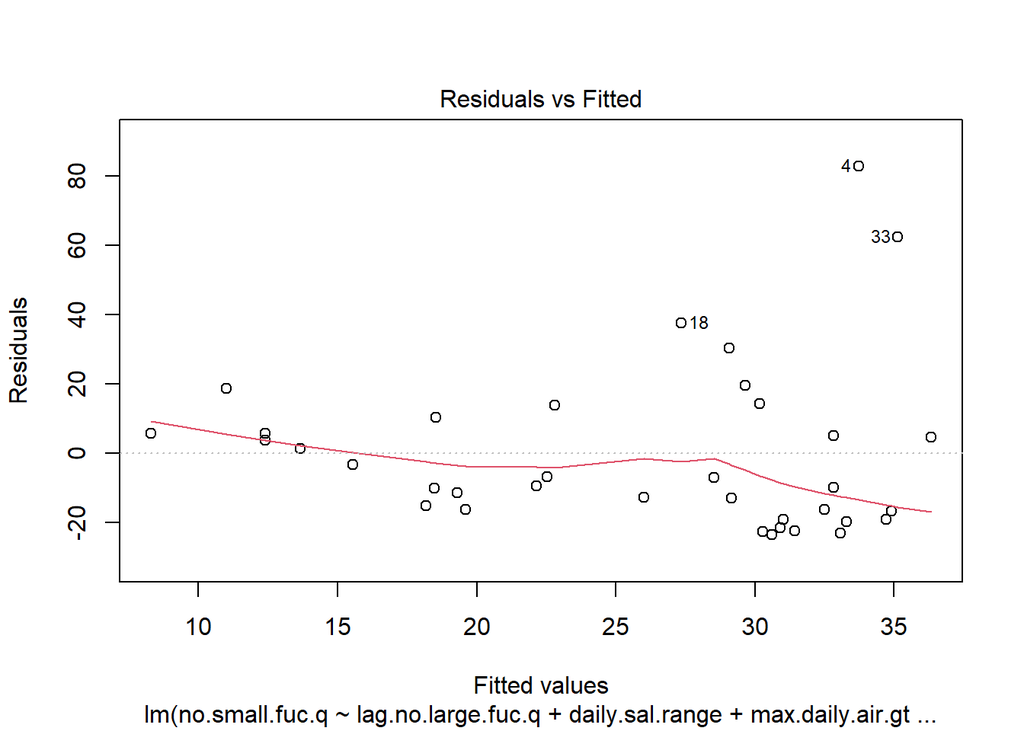

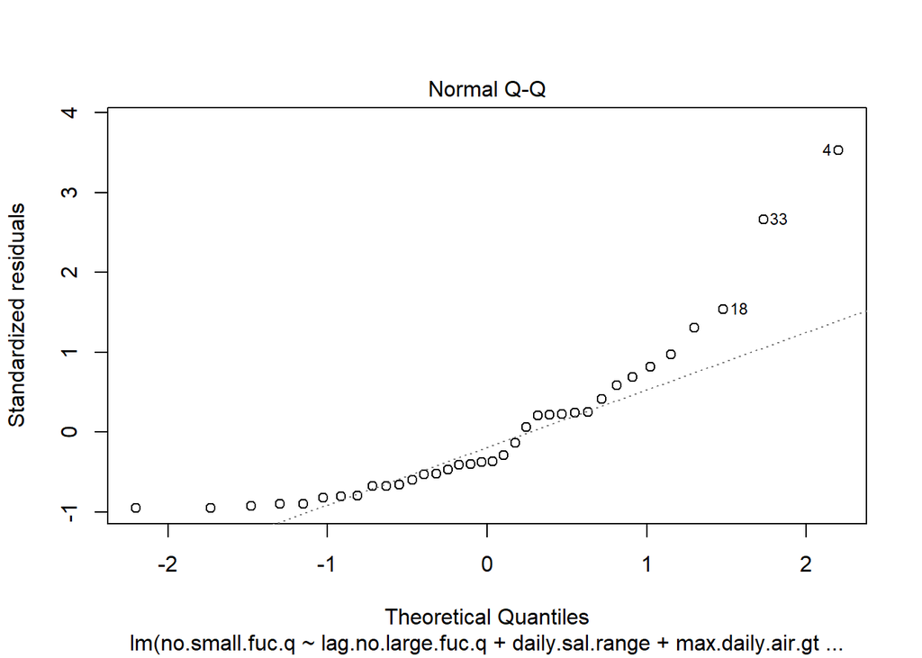

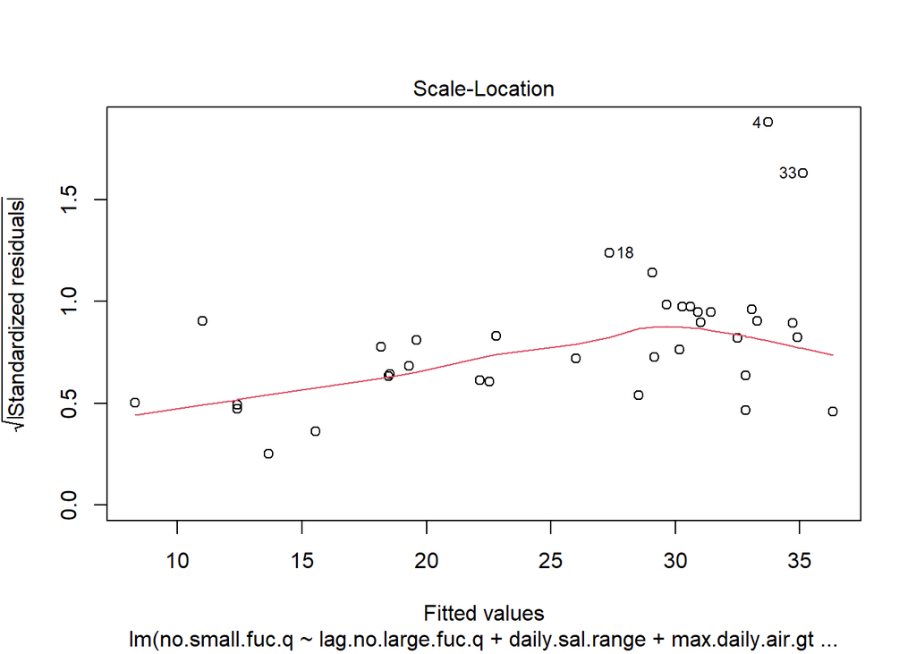

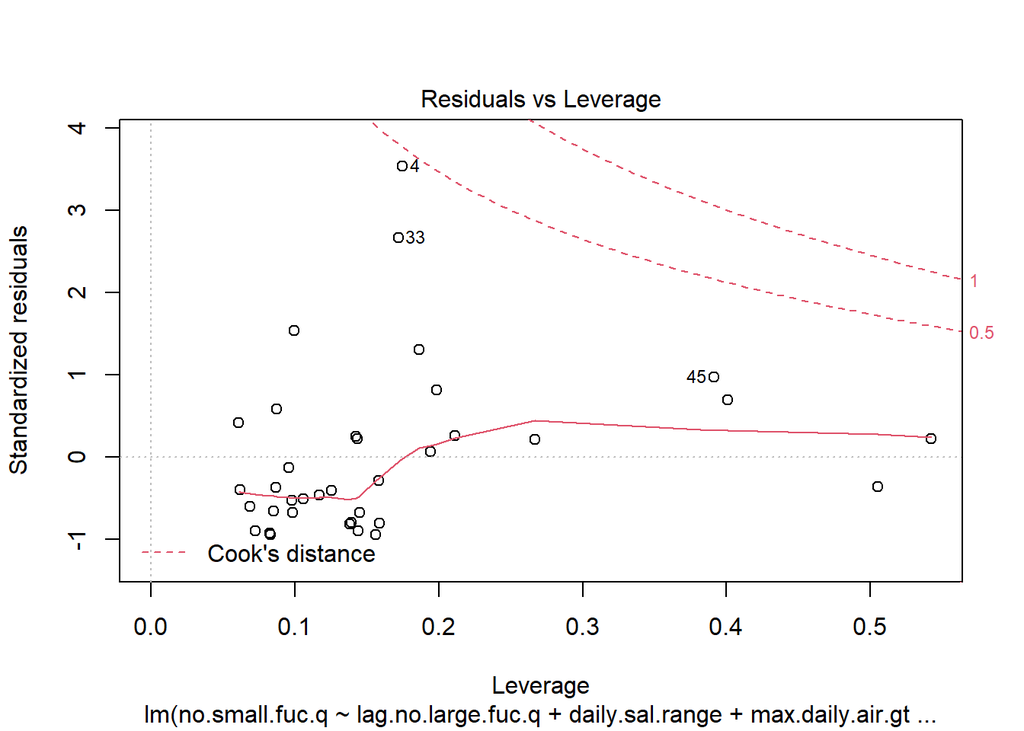

```r
m1 <- lm(no.small.fuc.q ~ lag.no.large.fuc.q + daily.sal.range + max.daily.air.gt26 + daily.ph.range + lag.no.large.fuc.q:max.daily.air.gt26, data=two.month)
plot(m1)
```

```r
m1
```

```
##
## Call:
## lm(formula = no.small.fuc.q ~ lag.no.large.fuc.q + daily.sal.range +
##     max.daily.air.gt26 + daily.ph.range + lag.no.large.fuc.q:max.daily.air.gt26,
##     data = two.month)
##
## Coefficients:
##                           (Intercept)                     lag.no.large.fuc.q
##                              43.36859                               -0.56716
##                       daily.sal.range                     max.daily.air.gt26
##                              -1.98120                               -0.39524
##                        daily.ph.range  lag.no.large.fuc.q:max.daily.air.gt26
##                              -0.97481                                0.03345
```

```r
summary(m1)
```

```
##
## Call:
## lm(formula = no.small.fuc.q ~ lag.no.large.fuc.q + daily.sal.range +
##     max.daily.air.gt26 + daily.ph.range + lag.no.large.fuc.q:max.daily.air.gt26,
##     data = two.month)
##
## Residuals:
##     Min      1Q  Median      3Q     Max
## -23.507 -16.291  -8.085   6.955  82.769
##
## Coefficients:
##                                       Estimate Std. Error t value Pr(>|t|)
## (Intercept)                           43.36859   17.13167   2.531   0.0168 *
## lag.no.large.fuc.q                    -0.56716    1.08098  -0.525   0.6037
## daily.sal.range                       -1.98120    1.40581  -1.409   0.1690
## max.daily.air.gt26                    -0.39524    0.78034  -0.506   0.6162
## daily.ph.range                        -0.97481    2.58670  -0.377   0.7089
## lag.no.large.fuc.q:max.daily.air.gt26  0.03345    0.08203   0.408   0.6863
## ---
## Signif. codes:  0 '***' 0.001 '**' 0.01 '*' 0.05 '.' 0.1 ' ' 1
##
## Residual standard error: 25.8 on 30 degrees of freedom
##   (25 observations deleted due to missingness)
## Multiple R-squared:  0.1027, Adjusted R-squared:  -0.04683
## F-statistic: 0.6868 on 5 and 30 DF,  p-value: 0.6371
```

```r
anova(m1)
```

```
## Analysis of Variance Table
##
## Response: no.small.fuc.q
##                                       Df  Sum Sq Mean Sq F value  Pr(>F)
## lag.no.large.fuc.q                     1    18.3   18.33  0.0275 0.86933
## daily.sal.range                        1  2031.7 2031.73  3.0516 0.09089 .
## max.daily.air.gt26                     1    46.9   46.91  0.0705 0.79249
## daily.ph.range                         1    78.8   78.78  0.1183 0.73326
## lag.no.large.fuc.q:max.daily.air.gt26  1   110.7  110.70  0.1663 0.68635
## Residuals                             30 19973.5  665.78
## ---
## Signif. codes:  0 '***' 0.001 '**' 0.01 '*' 0.05 '.' 0.1 ' ' 1
```

```r
confint(m1)
```

```
##                                            2.5 %     97.5 %
## (Intercept)                            8.3810510 78.3561243
## lag.no.large.fuc.q                    -2.7748120  1.6404978
## daily.sal.range                       -4.8522385  0.8898369
## max.daily.air.gt26                    -1.9889056  1.1984253
## daily.ph.range                        -6.2575546  4.3079373
## lag.no.large.fuc.q:max.daily.air.gt26 -0.1340773  0.2009735
```

Table

```r
tab_model(m1)
```

|  | no.small.fuc.q |  |  |
| --- | --- | --- | --- |
| Predictors | Estimates | CI | p |
| (Intercept) | 43.37 | 8.38 – 78.36 | **0.017** |
| lag.no.large.fuc.q | -0.57 | -2.77 – 1.64 | 0.604 |
| daily.sal.range | -1.98 | -4.85 – 0.89 | 0.169 |
| max.daily.air.gt26 | -0.40 | -1.99 – 1.20 | 0.616 |
| daily.ph.range | -0.97 | -6.26 – 4.31 | 0.709 |
| lag.no.large.fuc.q * max.daily.air.gt26 | 0.03 | -0.13 – 0.20 | 0.686 |
| Observations | 36 |  |  |
| R<sup>2</sup> / R<sup>2</sup> adjusted | 0.103 / -0.047 |  |  |

```r
tab_model(m1,
  show.ci = 0.95,
  show.se = TRUE,
  show.stat = FALSE,
  emph.p = TRUE,
  df.method = "kr",
  p.style = "numeric_stars",
  title = "Linear model for small thalli density",
  linebreak = TRUE,
  dv.labels = c("small thalli density"
      ),
  pred.labels = c(
    "(Intercept)",
    "large thalli density",
    "daily salinity range",
    "number of days with a maximum daily air temperature greater than 26C",
    "daily pH range",
    "large thalli density : number of days with a maximum daily air temperature greater than 26C"
      ),
  CSS = css_theme("cells")
  )
```

Linear model for small thalli density

small thalli density

Predictors

Estimates

std. Error

CI

p

(Intercept)

43.37 *

17.13

8.38 – 78.36

**0.017**

large thalli density

-0.57

1.08

-2.77 – 1.64

0.604

daily salinity range

-1.98

1.41

-4.85 – 0.89

0.169

number of days with a maximum daily air temperature greater than 26C

-0.40

0.78

-1.99 – 1.20

0.616

daily pH range

-0.97

2.59

-6.26 – 4.31

0.709

large thalli density : number of days with a maximum daily air temperature greater than 26C

0.03

0.08

-0.13 – 0.20

0.686

Observations

36

R<sup>2</sup> / R<sup>2</sup> adjusted

0.103 / -0.047

- p<0.05 ** p<0.01 *** p<0.001

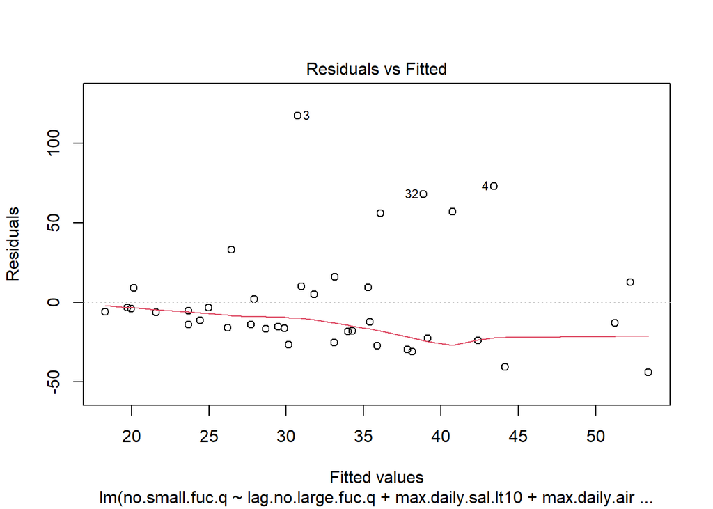

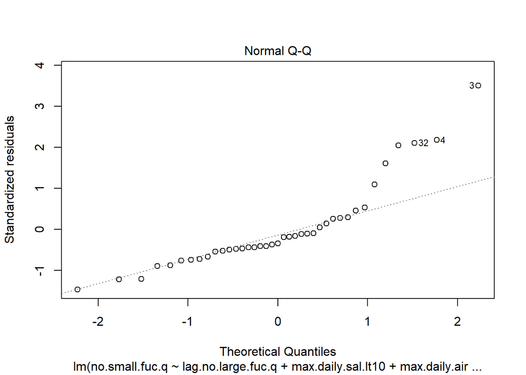

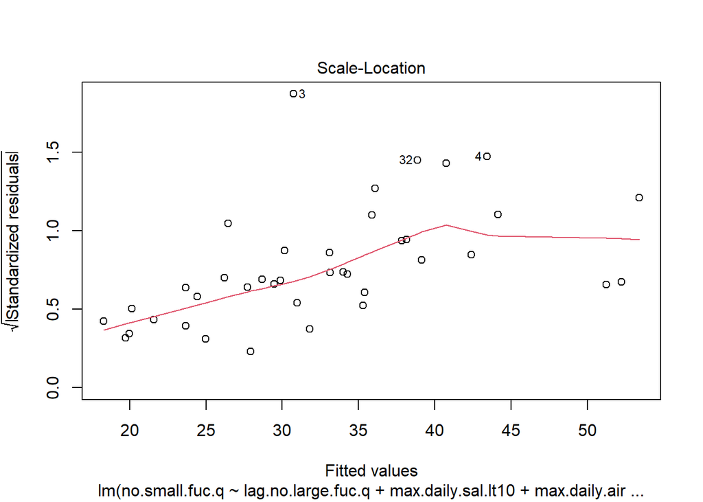

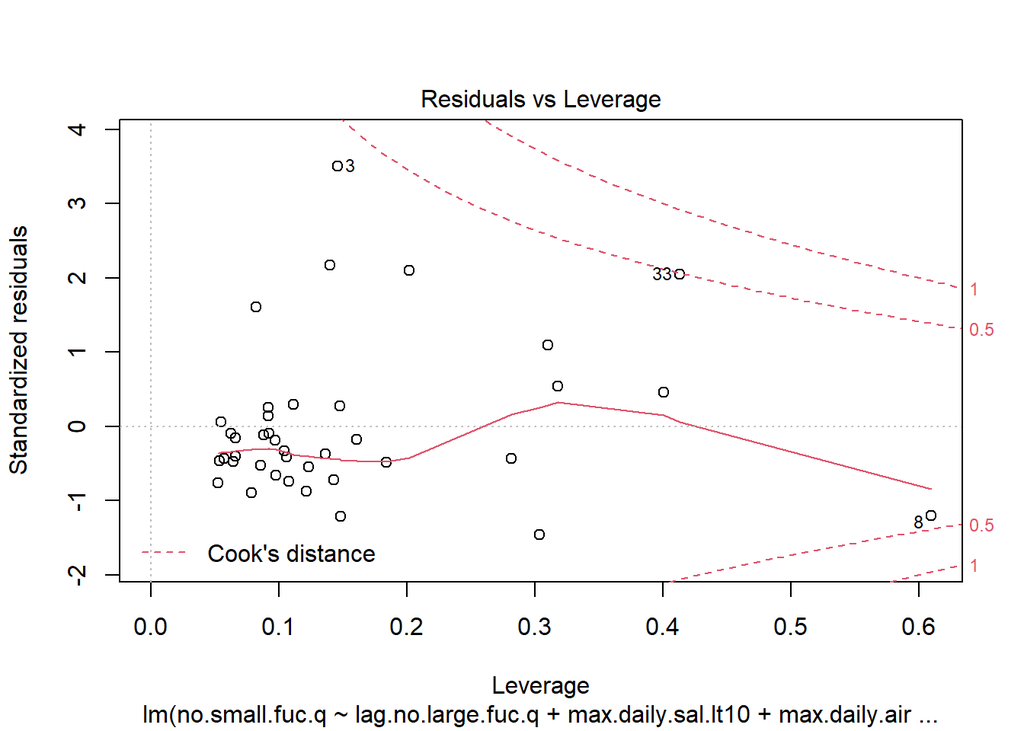

```r
m2 <- lm(no.small.fuc.q ~ lag.no.large.fuc.q + max.daily.sal.lt10 + max.daily.air.gt26 + max.daily.ph.gt8 + lag.no.large.fuc.q:max.daily.air.gt26, data=one.month)
plot(m2)
```

```r
m2
```

```
##
## Call:
## lm(formula = no.small.fuc.q ~ lag.no.large.fuc.q + max.daily.sal.lt10 +
##     max.daily.air.gt26 + max.daily.ph.gt8 + lag.no.large.fuc.q:max.daily.air.gt26,
##     data = one.month)
##
## Coefficients:
##                           (Intercept)                     lag.no.large.fuc.q
##                             15.677698                               1.537695
##                    max.daily.sal.lt10                     max.daily.air.gt26
##                             -0.384003                               0.051113
##                      max.daily.ph.gt8  lag.no.large.fuc.q:max.daily.air.gt26
##                              0.676607                               0.006729
```

```r
summary(m2)
```

```
##
## Call:
## lm(formula = no.small.fuc.q ~ lag.no.large.fuc.q + max.daily.sal.lt10 +
##     max.daily.air.gt26 + max.daily.ph.gt8 + lag.no.large.fuc.q:max.daily.air.gt26,
##     data = one.month)
##
## Residuals:
##     Min      1Q  Median      3Q     Max
## -44.297 -18.246 -11.544   8.979 117.353
##
## Coefficients:
##                                        Estimate Std. Error t value Pr(>|t|)
## (Intercept)                           15.677698  13.880438   1.129    0.267
## lag.no.large.fuc.q                     1.537695   1.412855   1.088    0.284
## max.daily.sal.lt10                    -0.384003   2.730995  -0.141    0.889
## max.daily.air.gt26                     0.051113   0.890520   0.057    0.955
## max.daily.ph.gt8                       0.676607   0.899435   0.752    0.457
## lag.no.large.fuc.q:max.daily.air.gt26  0.006729   0.102540   0.066    0.948
##
## Residual standard error: 36.23 on 33 degrees of freedom
##   (22 observations deleted due to missingness)
## Multiple R-squared:  0.06521,    Adjusted R-squared:  -0.07642
## F-statistic: 0.4604 on 5 and 33 DF,  p-value: 0.8027
```

```r
anova(m2)
```

```
## Analysis of Variance Table
##
## Response: no.small.fuc.q
##                                       Df Sum Sq Mean Sq F value Pr(>F)
## lag.no.large.fuc.q                     1   1580 1580.11  1.2039 0.2805
## max.daily.sal.lt10                     1     88   87.93  0.0670 0.7974
## max.daily.air.gt26                     1    611  610.56  0.4652 0.5000
## max.daily.ph.gt8                       1    737  737.30  0.5617 0.4589
## lag.no.large.fuc.q:max.daily.air.gt26  1      6    5.65  0.0043 0.9481
## Residuals                             33  43313 1312.53
```

```r
confint(m2)
```

```
##                                             2.5 %     97.5 %
## (Intercept)                           -12.5622666 43.9176619
## lag.no.large.fuc.q                     -1.3367796  4.4121702
## max.daily.sal.lt10                     -5.9402538  5.1722480
## max.daily.air.gt26                     -1.7606630  1.8628891
## max.daily.ph.gt8                       -1.1533069  2.5065202
## lag.no.large.fuc.q:max.daily.air.gt26  -0.2018911  0.2153492
```

Table

```r
tab_model(m2)
```

|  | no.small.fuc.q |  |  |
| --- | --- | --- | --- |
| Predictors | Estimates | CI | p |
| (Intercept) | 15.68 | -12.56 – 43.92 | 0.267 |
| lag.no.large.fuc.q | 1.54 | -1.34 – 4.41 | 0.284 |
| max.daily.sal.lt10 | -0.38 | -5.94 – 5.17 | 0.889 |
| max.daily.air.gt26 | 0.05 | -1.76 – 1.86 | 0.955 |
| max.daily.ph.gt8 | 0.68 | -1.15 – 2.51 | 0.457 |
| lag.no.large.fuc.q * max.daily.air.gt26 | 0.01 | -0.20 – 0.22 | 0.948 |
| Observations | 39 |  |  |
| R<sup>2</sup> / R<sup>2</sup> adjusted | 0.065 / -0.076 |  |  |

not sure what a negative R^2 adjusted means

#### Trying similar approach thing with adults

I’m curious to see if a similar of models has an effect on adult/large thalli. I’m curious to see if the same or different conditions affect adult thalli and if it provides some insight about a bottle neck event that occurs for juveniles. Not sure if it makes sense to have the lag adult density so I’m going to remove it.

Envirnomental data for 30 days starting 60 days from survey date (excludes the 30 days leading up to the survey date). Adult density is the mean.

Read in data

```r
#read in data
two.month<-read.csv(
      "https://raw.githubusercontent.com/Cmwegener/thesis/master/data/environment_field/envi.field.all.two.month.lag.csv",
    header = TRUE
  )
two.month$date<-as.Date(two.month$date, format = c("%Y-%m-%d"))
```

AIC

```r
#models
m1 <- lm(no.large.fuc.q ~ daily.sal.range + max.daily.air.gt26 + daily.ph.range, data=two.month)

m2 <- lm(no.large.fuc.q ~ max.daily.sal.lt10 + max.daily.air.gt26 + max.daily.ph.gt8, data=two.month)

m3 <- lm(no.large.fuc.q ~ daily.sal.range + max.daily.air.gt26, data=two.month)

m4 <- lm(no.large.fuc.q ~ daily.sal.range + daily.ph.range, data=two.month)

m5 <- lm(no.large.fuc.q ~ max.daily.sal.lt10 + max.daily.ph.gt8, data=two.month)

m6 <- lm(no.large.fuc.q ~ max.daily.sal.lt10 + max.daily.air.gt26, data=two.month)

m7 <- lm(no.large.fuc.q ~ max.daily.air.gt26, data=two.month)


#define list of models
models <- list(m1,m2,m3,m4,m5,m6,m7)

#specify model names- just keeping them the same
mod.names <- c('m1','m2','m3','m4', 'm5','m6','m7')

#calculate AIC of each model
aictab(cand.set = models, modnames = mod.names)
```

```
##
## Model selection based on AICc:
##
##    K   AICc Delta_AICc AICcWt Cum.Wt      LL
## m5 4 255.26       0.00   0.50   0.50 -123.09
## m1 5 257.21       1.95   0.19   0.68 -122.77
## m2 5 257.32       2.06   0.18   0.86 -122.83
## m4 4 257.82       2.57   0.14   1.00 -124.37
## m6 4 333.48      78.22   0.00   1.00 -162.36
## m7 3 336.47      81.21   0.00   1.00 -165.01
## m3 4 338.68      83.42   0.00   1.00 -164.96
```

**Top ranked**  
m5 <- lm(no.large.fuc.q ~ max.daily.sal.lt10 + max.daily.ph.gt8, data=two.month)

Fitting and analyzing the top ranked model.

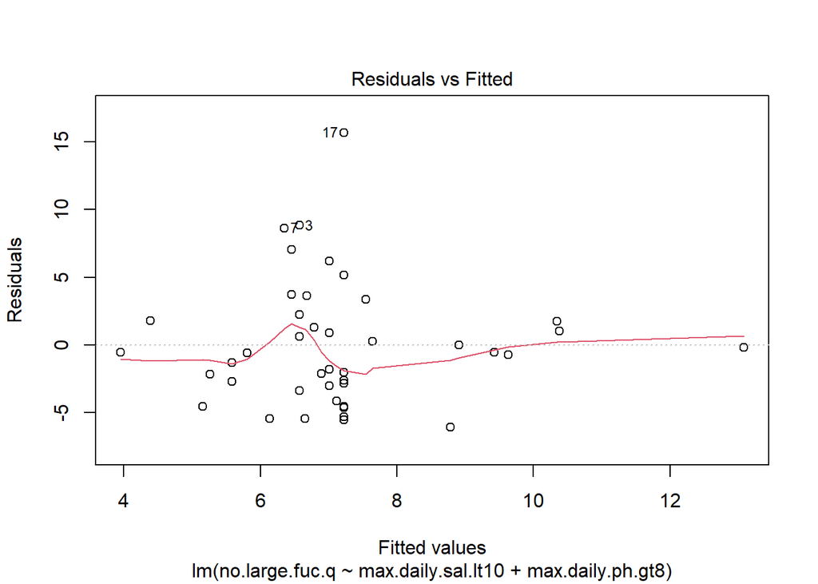

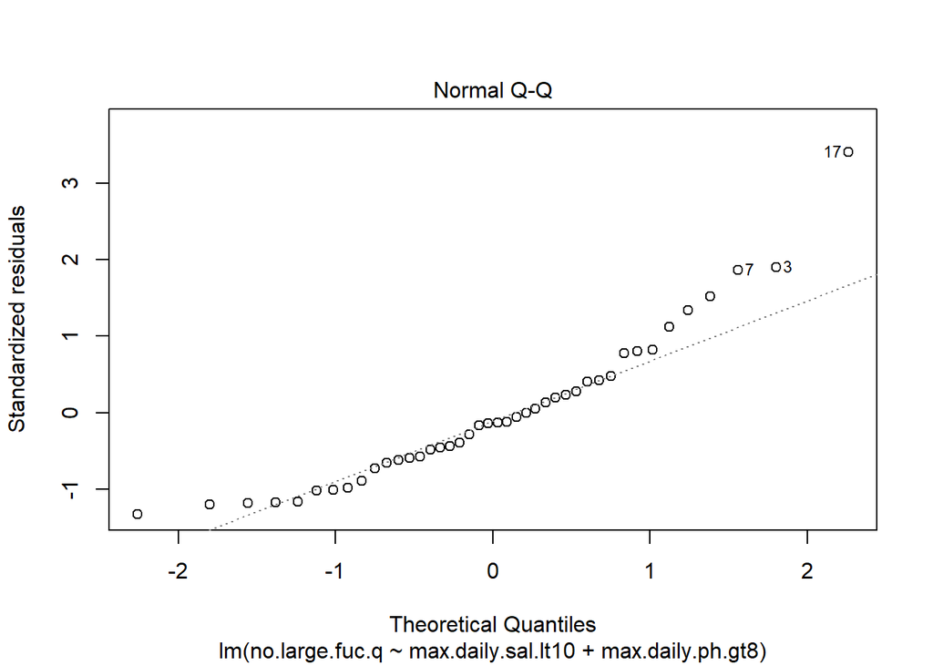

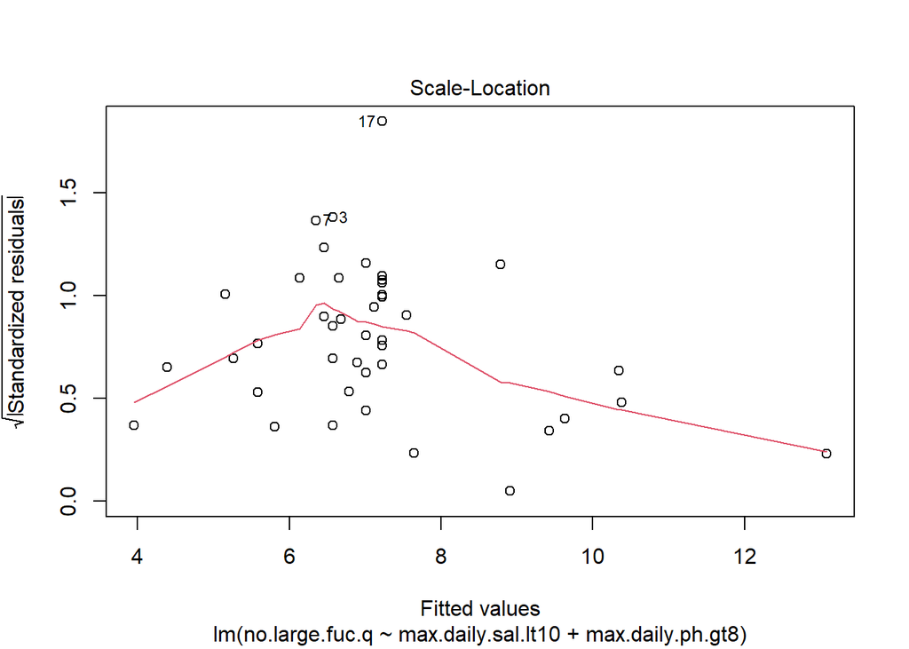

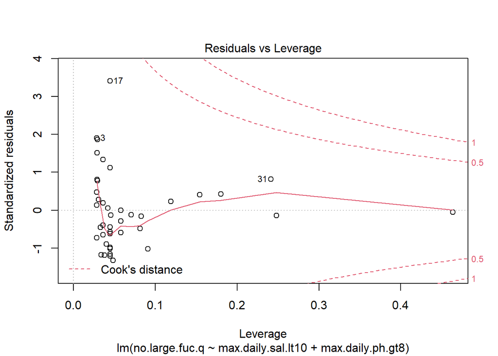

```r
m5 <- lm(no.large.fuc.q ~ max.daily.sal.lt10 + max.daily.ph.gt8, data=two.month)

plot(m5)
```

```r
m5
```

```
##
## Call:
## lm(formula = no.large.fuc.q ~ max.daily.sal.lt10 + max.daily.ph.gt8,
##     data = two.month)
##
## Coefficients:
##        (Intercept)  max.daily.sal.lt10    max.daily.ph.gt8
##             7.2260              0.4215             -0.1091
```

```r
summary(m5)
```

```
##
## Call:
## lm(formula = no.large.fuc.q ~ max.daily.sal.lt10 + max.daily.ph.gt8,
##     data = two.month)
##
## Residuals:
##     Min      1Q  Median      3Q     Max
## -6.0880 -2.9623 -0.5797  1.7961 15.6740
##
## Coefficients:
##                    Estimate Std. Error t value Pr(>|t|)
## (Intercept)          7.2260     0.9960   7.255  9.6e-09 ***
## max.daily.sal.lt10   0.4215     0.2052   2.054   0.0467 *
## max.daily.ph.gt8    -0.1091     0.0934  -1.168   0.2497
## ---
## Signif. codes:  0 '***' 0.001 '**' 0.01 '*' 0.05 '.' 0.1 ' ' 1
##
## Residual standard error: 4.706 on 39 degrees of freedom
##   (19 observations deleted due to missingness)
## Multiple R-squared:  0.1132, Adjusted R-squared:  0.06771
## F-statistic: 2.489 on 2 and 39 DF,  p-value: 0.0961
```

```r
anova(m5)
```

```
## Analysis of Variance Table
##
## Response: no.large.fuc.q
##                    Df Sum Sq Mean Sq F value  Pr(>F)
## max.daily.sal.lt10  1  80.00  79.997  3.6125 0.06476 .
## max.daily.ph.gt8    1  30.23  30.235  1.3653 0.24971
## Residuals          39 863.63  22.144
## ---
## Signif. codes:  0 '***' 0.001 '**' 0.01 '*' 0.05 '.' 0.1 ' ' 1
```

```r
confint(m5)
```

```
##                          2.5 %     97.5 %
## (Intercept)         5.21142291 9.24066561
## max.daily.sal.lt10  0.00644685 0.83659773
## max.daily.ph.gt8   -0.29804480 0.07978105
```

Table

```r
tab_model(m5)
```

|  | no.large.fuc.q |  |  |
| --- | --- | --- | --- |
| Predictors | Estimates | CI | p |
| (Intercept) | 7.23 | 5.21 – 9.24 | **<0.001** |
| max.daily.sal.lt10 | 0.42 | 0.01 – 0.84 | **0.047** |
| max.daily.ph.gt8 | -0.11 | -0.30 – 0.08 | 0.250 |
| Observations | 42 |  |  |
| R<sup>2</sup> / R<sup>2</sup> adjusted | 0.113 / 0.068 |  |  |

Trying this again with without the ph terms because there’s no compelling lit evidence to support it. More interested in salniity events and heat. I’d like to compare what effects adults vs juveniles so should I keep the pH terms? AIC

```r
#models
m1 <- lm(no.large.fuc.q ~ daily.sal.range + max.daily.air.gt26, data=two.month)

m2 <- lm(no.large.fuc.q ~ max.daily.sal.lt10 + max.daily.air.gt26, data=two.month)

m3 <- lm(no.large.fuc.q ~ daily.sal.range, data=two.month)

m4 <- lm(no.large.fuc.q ~ max.daily.sal.lt10, data=two.month)

m5 <- lm(no.large.fuc.q ~ max.daily.air.gt26, data=two.month)



#define list of models
models <- list(m1,m2,m3,m4,m5)

#specify model names- just keeping them the same
mod.names <- c('m1','m2','m3','m4', 'm5')

#calculate AIC of each model
aictab(cand.set = models, modnames = mod.names)
```

```
##
## Model selection based on AICc:
##
##    K   AICc Delta_AICc AICcWt Cum.Wt      LL
## m4 3 332.63       0.00   0.51   0.51 -163.09
## m2 4 333.48       0.85   0.33   0.84 -162.36
## m5 3 336.47       3.84   0.07   0.92 -165.01
## m3 3 337.02       4.39   0.06   0.98 -165.28
## m1 4 338.68       6.05   0.02   1.00 -164.96
```

```r
tab_model(m4)
```

|  | no.large.fuc.q |  |  |
| --- | --- | --- | --- |
| Predictors | Estimates | CI | p |
| (Intercept) | 6.58 | 5.36 – 7.80 | **<0.001** |
| max.daily.sal.lt10 | 0.38 | 0.02 – 0.74 | **0.040** |
| Observations | 57 |  |  |
| R<sup>2</sup> / R<sup>2</sup> adjusted | 0.074 / 0.057 |  |  |

Positive effect of low salinity events for larger thalli density??? Not sure about my approach here. More of a curiousty quest but it’d be nice in the discussion to compare what events affects juveniles vs adults.